# EDA Danych dotyczących Irysów

## O Danych

Zbiór danych zawiera informacje o trzech gatunkach irysów: Iris setosa, Iris versicolor, i Iris virginica.

Dane obejmują pomiary czterech cech: długość i szerokość działki kielicha oraz długość i szerokość płatka.

Każdy wiersz w zbiorze danych reprezentuje pojedynczy kwiat, a wartości pomiarów są podane w centymetrach.

Zbiór składa się z 150 próbek, po 50 dla każdego gatunku, i jest szeroko stosowany jako podstawowy zbiór danych do testowania algorytmów klasyfikacji oraz w nauce o danych i uczeniu maszynowym.

Kolumny:

- **długość kielicha (sepal length)** - Długość kielicha w cm
- **szerokość kielicha (sepal width)** - Szerokość kielicha w cm
- **długość płatka (petal length)** - Długość płatka w cm
- **szerokość płatka (petal width)** - Szerokość płatka w cm
- **klasa (class)** - Klasa irysa (setosa, versicolor, virginica)

# Analiza wtępna

```
<class 'pandas.core.frame.DataFrame'>
RangeIndex: 150 entries, 0 to 149
Data columns (total 5 columns):
 #   Column                            Non-Null Count  Dtype
---  ------                            --------------  -----
 0   długość kielicha (sepal length)   150 non-null    float64
 1   szerokość kielicha (sepal width)  150 non-null    float64
 2   długość płatka (petal length)     150 non-null    float64
 3   szerokość płatka (petal width)    150 non-null    float64
 4   klasa (class)                     150 non-null    object
dtypes: float64(4), object(1)
memory usage: 6.0+ KB
```

**Zestaw danych zawiera 150 wartości, 5 kolumn, 4 z nich zawieraja dane (float) a jedna dane typu (object). Do tego mamy podaną ilość użytej pamięci ponad 6KB. Dane są kompletne, nie zauważyłem żadnych brakujących wartości, brak pustych rekordów**

```
długość kielicha (sepal length)     35
szerokość kielicha (sepal width)    23
długość płatka (petal length)       43
szerokość płatka (petal width)      22
klasa (class)                        3
dtype: int64
```

```
klasa (class)
Iris-setosa        50
Iris-versicolor    50
Iris-virginica     50
Name: count, dtype: int64
```

|  | długość kielicha (sepal length) | szerokość kielicha (sepal width) | długość płatka (petal length) | szerokość płatka (petal width) |
| --- | --- | --- | --- | --- |
| count | 150.000000 | 150.000000 | 150.000000 | 150.000000 |
| mean | 5.843333 | 3.054000 | 3.758667 | 1.198667 |
| std | 0.828066 | 0.433594 | 1.764420 | 0.763161 |
| min | 4.300000 | 2.000000 | 1.000000 | 0.100000 |
| 25% | 5.100000 | 2.800000 | 1.600000 | 0.300000 |
| 50% | 5.800000 | 3.000000 | 4.350000 | 1.300000 |
| 75% | 6.400000 | 3.300000 | 5.100000 | 1.800000 |
| max | 7.900000 | 4.400000 | 6.900000 | 2.500000 |

**Z danych wynika że mamy 150 próbek kwiatów irysów które dzielą się na 3 rodzaje po 50 próbek w każdej, długość kielicha mieści się pomiędzy 4.3cm do 7.9cm a jego szerokość od 2cm do 4.4cm, średnio długość i szerokość kielicha to kolejno 5.8cm i 3cm. Natomiast jeśli chodzi o płatki to minimalna długość to 1cm zaś maksymalna to 6.9cm idąc dalej szerokość balansuje pomiedzy 0.1cm do 2.5cm.**

## Analiza wartości brakujących

[output not shown]

150 rows × 5 columns

```
długość kielicha (sepal length)     0
szerokość kielicha (sepal width)    0
długość płatka (petal length)       0
szerokość płatka (petal width)      0
klasa (class)                       0
dtype: int64
```

**Brak pustych rekordów**

## Analiza koleracji zmiennych

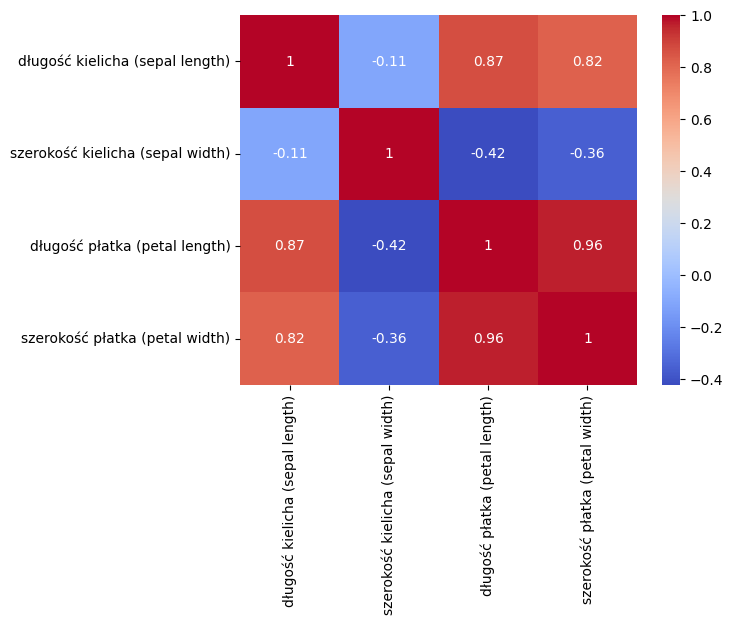

# Porównania

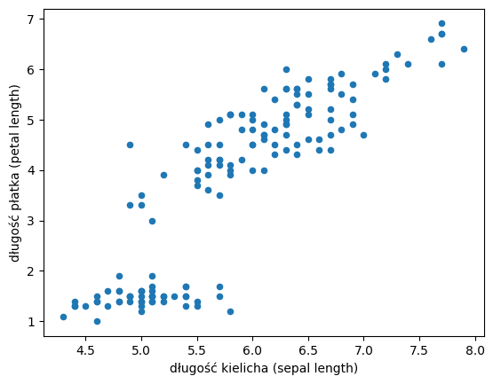

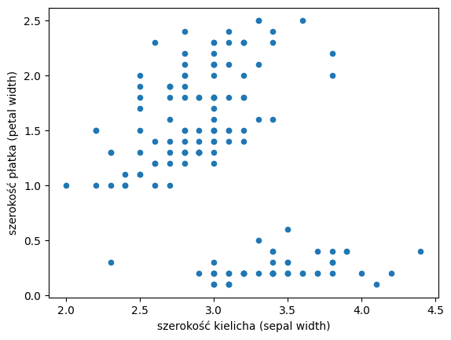

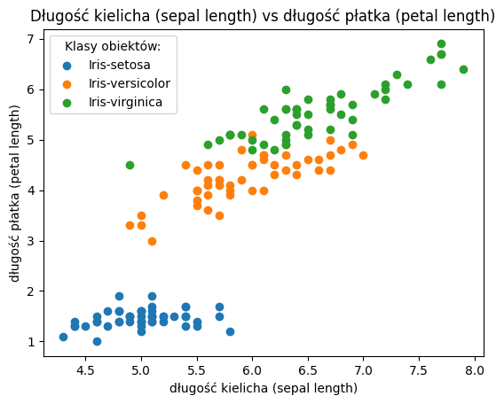

**Długość płatka tego gatunku mieści sie między 1 cm do 7cm,długość kielicha to zakres 4.5cm do 8cm. Najwiecej gatunków występuje w zakresie3.5cm do 6cm długości płatka i od5.5cm do 7cm długości kielicha.**

# Wartości odstające

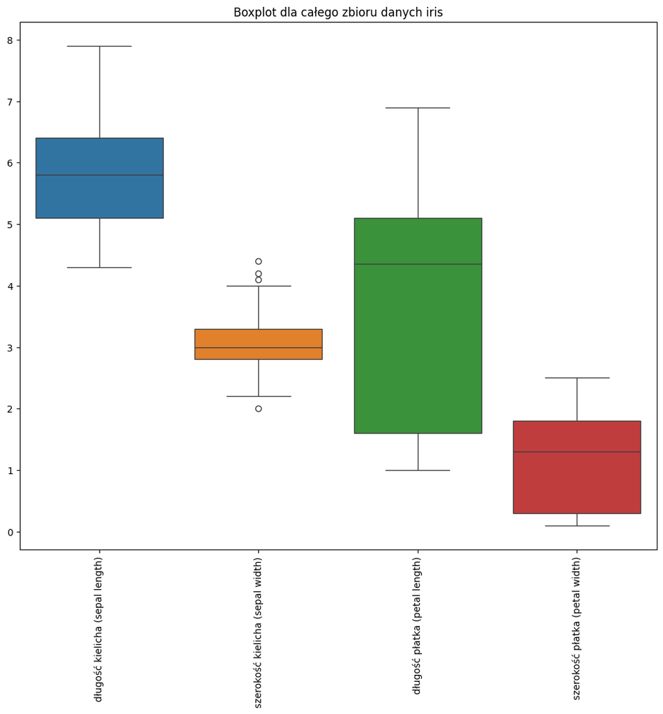

- Wartości odstające wytępują jedynie w przypadku szerokości kielicha

## Podsumowanie

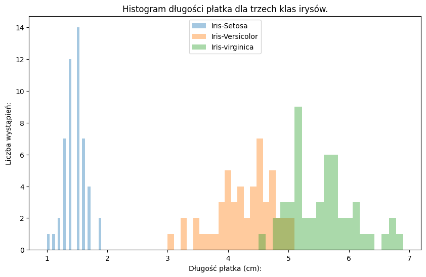

#### Iris Setosa

- Z histogramu wynika że przedział długości płatka nie wychodzi z zakresu od 1cm do 2cm
- Rozkład jest wąski oraz próbki z tego gatunku są bardzo podobne

#### Iris Versicolor

- Jego zakres wacha sie w przedziale od 3cm do 5cm
- Najwiecewj próbek mieści sie w przediale od 4cm do 5cm długości płatka
- Najbardziej usredniona długość płatków ze wszystkich 3 gatunków kwiatów

#### Iris Virgnica

- Ten gatunek charakteryzuje sie najwiekszą różnorodnością długości płatków od 4,5cm do 6.9cm
- Najczęściej występująca długośc płatka to ok. 5cm

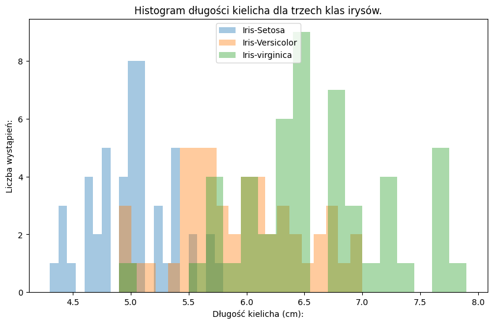

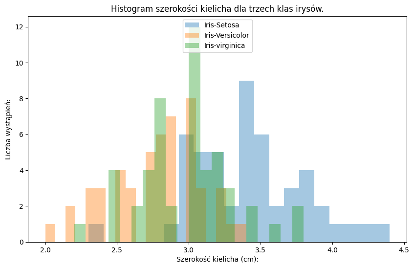

## Iris Verisicolor

- Szerokość kielicha wacha sie od 2cm do 3,5cm, długość zaś od 5 do 7cm
- Jest najbardziej uśredniony ze wszystkich 3 gatunków
- Najwiecej próbek ma 3cm szerokości kielicha oraz ok 5,5 cm jego długości

## Iris Virginica

- Ten gatunek ma najwieksze kielichy
- Najwiecej próbek ma ok 3cm szerokości kielicha i 6,5cm długości
- zakres długości kielicha miesci sie od 5cm do 8cm, szerokość od 2,3cm do 3,8cm
- Najwieksze zróżnicowanie wielkości kielicha ze wszystkich gatunków